# Aim – Find the 10 most contributing features for a given response variable.

TU Dublin Tallaght Campus Data Analysis and Programming

Department of Computing Contribution: 50%

Individual Project Lecturer Rajesh Jaiswal

Project Submission Date: 8nd May 2023, 6 pm

https://www.kaggle.com/zazaucd

https://www.kaggle.com/datasets/rohitsahoo/employee

https://www.kaggle.com/code/zazaucd/ibm-employee-data-analytics-w-random-forest

- Zaur Gouliev (X00205702)
- x00205702@mytudublin.ie

# Task 1 – Data Description and Cleaning

```python
import pandas as pd
import matplotlib.pyplot as plt
import seaborn as sns
import numpy as np
from scipy.stats import chi2_contingency, ttest_ind, f_oneway
import statsmodels.api as sm
from sklearn.metrics import accuracy_score, precision_score
from sklearn.linear_model import LinearRegression
from sklearn.decomposition import PCA
from statsmodels.formula.api import ols
from sklearn.preprocessing import StandardScaler
from sklearn.impute import SimpleImputer
plt.style.use('ggplot') # Set a style for the plots
sns.set_style('whitegrid')
```

```python
df = pd.read_csv('CA2_data.csv')
```

## The first few rows of the data

```python
print(df.head())
```

```
   Age Attrition     BusinessTravel  DailyRate              Department  \
0   41       Yes      Travel_Rarely       1102                   Sales
1   49        No  Travel_Frequently        279  Research & Development
2   37       Yes      Travel_Rarely       1373  Research & Development
3   33        No  Travel_Frequently       1392  Research & Development
4   27        No      Travel_Rarely        591  Research & Development

   DistanceFromHome      Education EducationField  EmployeeCount  \
0                 1        College  Life Sciences              1
1                 8  Below College  Life Sciences              1
2                 2        College          Other              1
3                 3         Master  Life Sciences              1
4                 2  Below College        Medical              1

   EmployeeNumber  ... RelationshipSatisfaction StandardHours  \
```

[output cut: 28 more lines]

## Describe the data

```python
print(df.describe())
```

```
               Age    DailyRate  DistanceFromHome  EmployeeCount  \
count  1470.000000  1470.000000       1470.000000         1470.0
mean     36.923810   802.485714          9.192517            1.0
std       9.135373   403.509100          8.106864            0.0
min      18.000000   102.000000          1.000000            1.0
25%      30.000000   465.000000          2.000000            1.0
50%      36.000000   802.000000          7.000000            1.0
75%      43.000000  1157.000000         14.000000            1.0
max      60.000000  1499.000000         29.000000            1.0

       EmployeeNumber   HourlyRate  JobInvolvement     JobLevel  \
count     1470.000000  1470.000000     1470.000000  1470.000000
mean      1024.865306    65.891156        2.729932     2.063946
std        602.024335    20.329428        0.711561     1.106940
min          1.000000    30.000000        1.000000     1.000000
25%        491.250000    48.000000        2.000000     1.000000
50%       1020.500000    66.000000        3.000000     2.000000
75%       1555.750000    83.750000        3.000000     3.000000
max       2068.000000   100.000000        4.000000     5.000000

       NumCompaniesWorked  PercentSalaryHike  PerformanceRating  \
count         1470.000000        1470.000000        1470.000000
mean             2.693197          15.209524           3.153741
std              2.498009           3.659938           0.360824
min              0.000000          11.000000           3.000000
25%              1.000000          12.000000           3.000000
50%              2.000000          14.000000           3.000000
75%              4.000000          18.000000           3.000000
max              9.000000          25.000000           4.000000

       RelationshipSatisfaction  StandardHours  StockOptionLevel  \
count               1470.000000         1470.0       1470.000000
mean                   2.712245           80.0          0.793878
std                    1.081209            0.0          0.852077
min                    1.000000           80.0          0.000000
25%                    2.000000           80.0          0.000000
50%                    3.000000           80.0          1.000000
75%                    4.000000           80.0          1.000000
max                    4.000000           80.0          3.000000

       TotalWorkingYears  TrainingTimesLastYear  YearsAtCompany  \
count        1470.000000            1470.000000     1470.000000
mean           11.279592               2.799320        7.008163
std             7.780782               1.289271        6.126525
min             0.000000               0.000000        0.000000
25%             6.000000               2.000000        3.000000
50%            10.000000               3.000000        5.000000
75%            15.000000               3.000000        9.000000
max            40.000000               6.000000       40.000000

       YearsInCurrentRole  YearsSinceLastPromotion  YearsWithCurrManager
count         1470.000000              1470.000000           1470.000000
mean             4.229252                 2.187755              4.123129
std              3.623137                 3.222430              3.568136
min              0.000000                 0.000000              0.000000
25%              2.000000                 0.000000              2.000000
50%              3.000000                 1.000000              3.000000
75%              7.000000                 3.000000              7.000000
max             18.000000                15.000000             17.000000
```

## The shape of the data

```python
print('Shape of the data:', df.shape)
```

```
Shape of the data: (1470, 35)
```

## The number of variables

```python
print("\nNumber of variables:", len(df.columns))
```

```
Number of variables: 35
```

## The data types of each variable

```python
print('Data types:')
print(df.dtypes)
```

```
Data types:
Age                          int64
Attrition                   object
BusinessTravel              object
DailyRate                    int64
Department                  object
DistanceFromHome             int64
Education                   object
EducationField              object
EmployeeCount                int64
EmployeeNumber               int64
EnvironmentSatisfaction     object
Gender                      object
HourlyRate                   int64
JobInvolvement               int64
JobLevel                     int64
JobRole                     object
JobSatisfaction             object
MaritalStatus               object
MonthlyIncome               object
MonthlyRate                 object
NumCompaniesWorked           int64
Over18                      object
OverTime                    object
PercentSalaryHike            int64
PerformanceRating            int64
RelationshipSatisfaction     int64
StandardHours                int64
StockOptionLevel             int64
TotalWorkingYears            int64
TrainingTimesLastYear        int64
WorkLifeBalance             object
YearsAtCompany               int64
YearsInCurrentRole           int64
YearsSinceLastPromotion      int64
YearsWithCurrManager         int64
dtype: object
```

```python
print('Description:')
print(df.describe(include='all'))
```

```
Description:
                Age Attrition BusinessTravel    DailyRate  \
count   1470.000000      1470           1470  1470.000000
unique          NaN         2              3          NaN
top             NaN        No  Travel_Rarely          NaN
freq            NaN      1233           1043          NaN
mean      36.923810       NaN            NaN   802.485714
std        9.135373       NaN            NaN   403.509100
min       18.000000       NaN            NaN   102.000000
25%       30.000000       NaN            NaN   465.000000
50%       36.000000       NaN            NaN   802.000000
75%       43.000000       NaN            NaN  1157.000000
max       60.000000       NaN            NaN  1499.000000

                    Department  DistanceFromHome Education EducationField  \
count                     1470       1470.000000      1470           1470
unique                       3               NaN         5              6
top     Research & Development               NaN  Bachelor  Life Sciences
freq                       961               NaN       572            606
mean                       NaN          9.192517       NaN            NaN
std                        NaN          8.106864       NaN            NaN
min                        NaN          1.000000       NaN            NaN
25%                        NaN          2.000000       NaN            NaN
50%                        NaN          7.000000       NaN            NaN
75%                        NaN         14.000000       NaN            NaN
max                        NaN         29.000000       NaN            NaN

        EmployeeCount  EmployeeNumber  ... RelationshipSatisfaction  \
count          1470.0     1470.000000  ...              1470.000000
unique            NaN             NaN  ...                      NaN
top               NaN             NaN  ...                      NaN
freq              NaN             NaN  ...                      NaN
mean              1.0     1024.865306  ...                 2.712245
std               0.0      602.024335  ...                 1.081209
min               1.0        1.000000  ...                 1.000000
25%               1.0      491.250000  ...                 2.000000
50%               1.0     1020.500000  ...                 3.000000
75%               1.0     1555.750000  ...                 4.000000
max               1.0     2068.000000  ...                 4.000000

```

[output cut: 25 more lines]

```

       YearsInCurrentRole YearsSinceLastPromotion YearsWithCurrManager
count         1470.000000             1470.000000          1470.000000
unique                NaN                     NaN                  NaN
top                   NaN                     NaN                  NaN
freq                  NaN                     NaN                  NaN
mean             4.229252                2.187755             4.123129
std              3.623137                3.222430             3.568136
min              0.000000                0.000000             0.000000
25%              2.000000                0.000000             2.000000
50%              3.000000                1.000000             3.000000
75%              7.000000                3.000000             7.000000
max             18.000000               15.000000            17.000000

[11 rows x 35 columns]
```

## The number of unique values in each variable

```python
print('Number of unique values:')
print(df.nunique())
```

```
Number of unique values:
Age                           43
Attrition                      2
BusinessTravel                 3
DailyRate                    886
Department                     3
DistanceFromHome              29
Education                      5
EducationField                 6
EmployeeCount                  1
EmployeeNumber              1470
EnvironmentSatisfaction        4
Gender                         2
HourlyRate                    71
JobInvolvement                 4
JobLevel                       5
JobRole                        9
JobSatisfaction                4
MaritalStatus                  3
MonthlyIncome               1350
MonthlyRate                 1427
NumCompaniesWorked            10
Over18                         1
OverTime                       2
PercentSalaryHike             15
PerformanceRating              2
RelationshipSatisfaction       4
StandardHours                  1
StockOptionLevel               4
TotalWorkingYears             40
TrainingTimesLastYear          7
WorkLifeBalance                4
YearsAtCompany                37
YearsInCurrentRole            19
YearsSinceLastPromotion       16
YearsWithCurrManager          18
dtype: int64
```

## Check variable types: nominal, ordinal, discrete or continious

```python
# A method I created in another data analytics project
for col in df.columns:
    if df[col].dtype == 'object':
        print(col + ': Nominal') # Check if an object (nominal)
    elif len(df[col].unique()) <= 10: # Check if ordinal
        print(col + ': Ordinal')
    elif df[col].dtype == 'int64':
        print(col + ': Discrete') # Check if discrete
    else:
        print(col + ': Continuous') # Check if continious
```

```
Age: Discrete
Attrition: Nominal
BusinessTravel: Nominal
DailyRate: Discrete
Department: Nominal
DistanceFromHome: Discrete
Education: Nominal
EducationField: Nominal
EmployeeCount: Ordinal
EmployeeNumber: Discrete
EnvironmentSatisfaction: Nominal
Gender: Nominal
HourlyRate: Discrete
JobInvolvement: Ordinal
JobLevel: Ordinal
JobRole: Nominal
JobSatisfaction: Nominal
MaritalStatus: Nominal
MonthlyIncome: Nominal
MonthlyRate: Nominal
NumCompaniesWorked: Ordinal
Over18: Nominal
OverTime: Nominal
PercentSalaryHike: Discrete
PerformanceRating: Ordinal
RelationshipSatisfaction: Ordinal
StandardHours: Ordinal
StockOptionLevel: Ordinal
TotalWorkingYears: Discrete
TrainingTimesLastYear: Ordinal
WorkLifeBalance: Nominal
YearsAtCompany: Discrete
YearsInCurrentRole: Discrete
YearsSinceLastPromotion: Discrete
YearsWithCurrManager: Discrete
```

## Easier method using value counts (this checks the data types)

```python
print("\nNumber of Nominal/Ordinal and Discrete/Continuous variables:")
print(df.dtypes.value_counts())
```

```
Number of Nominal/Ordinal and Discrete/Continuous variables:
int64     20
object    15
dtype: int64
```

## Define our response and explanatory variables

```python
response_var = 'Attrition'
```

```python
explanatory_vars = ['Age', 'BusinessTravel', 'DailyRate', 'Department', 'DistanceFromHome', 'Education',
                    'EducationField', 'EmployeeCount', 'EmployeeNumber', 'EnvironmentSatisfaction',
                    'Gender', 'HourlyRate', 'JobInvolvement', 'JobLevel', 'JobRole', 'JobSatisfaction',
                    'MaritalStatus', 'MonthlyIncome', 'MonthlyRate', 'NumCompaniesWorked', 'Over18',
                    'OverTime', 'PercentSalaryHike', 'PerformanceRating', 'RelationshipSatisfaction',
                    'StandardHours', 'StockOptionLevel', 'TotalWorkingYears', 'TrainingTimesLastYear',
                    'WorkLifeBalance', 'YearsAtCompany', 'YearsInCurrentRole', 'YearsSinceLastPromotion',
                    'YearsWithCurrManager']
```

## We can check 'Age', 'DailyRate', 'DistancFromHome', 'HourlyRate', 'NumCompaniesWorked', 'PercentSalaryHike', 'PerformanceRating', 'RelationshipSatisfication'.

### We check for the center (mean/median), the spread using standard deviation and the range (min to max). The justifications is that the mean and median will give us a good idea of the center of the variable not including the outliers, while the standard deviation will tell us how it spreads while the range gives us the min and max which is important to know

```python
num_cols = ['Age', 'DailyRate', 'DistanceFromHome', 'HourlyRate',
            'NumCompaniesWorked', 'PercentSalaryHike',
            'PerformanceRating', 'RelationshipSatisfaction']
num_df = df[num_cols]
```

```python
summary = num_df.describe()
```

```python
print(summary)
```

```
               Age    DailyRate  DistanceFromHome   HourlyRate  \
count  1470.000000  1470.000000       1470.000000  1470.000000
mean     36.923810   802.485714          9.192517    65.891156
std       9.135373   403.509100          8.106864    20.329428
min      18.000000   102.000000          1.000000    30.000000
25%      30.000000   465.000000          2.000000    48.000000
50%      36.000000   802.000000          7.000000    66.000000
75%      43.000000  1157.000000         14.000000    83.750000
max      60.000000  1499.000000         29.000000   100.000000

       NumCompaniesWorked  PercentSalaryHike  PerformanceRating  \
count         1470.000000        1470.000000        1470.000000
mean             2.693197          15.209524           3.153741
std              2.498009           3.659938           0.360824
min              0.000000          11.000000           3.000000
25%              1.000000          12.000000           3.000000
50%              2.000000          14.000000           3.000000
75%              4.000000          18.000000           3.000000
max              9.000000          25.000000           4.000000

       RelationshipSatisfaction
count               1470.000000
mean                   2.712245
std                    1.081209
min                    1.000000
25%                    2.000000
50%                    3.000000
75%                    4.000000
max                    4.000000
```

## Check and fix the data for inconsistency or non-entry.

```python
df.info()
```

```
<class 'pandas.core.frame.DataFrame'>
RangeIndex: 1470 entries, 0 to 1469
Data columns (total 35 columns):
 #   Column                    Non-Null Count  Dtype
---  ------                    --------------  -----
 0   Age                       1470 non-null   int64
 1   Attrition                 1470 non-null   object
 2   BusinessTravel            1470 non-null   object
 3   DailyRate                 1470 non-null   int64
 4   Department                1470 non-null   object
 5   DistanceFromHome          1470 non-null   int64
 6   Education                 1470 non-null   object
 7   EducationField            1470 non-null   object
 8   EmployeeCount             1470 non-null   int64
 9   EmployeeNumber            1470 non-null   int64
```

[output cut: 27 more lines]

```python
missing_cols = df.columns[df.isnull().any()]
```

```python
df.dropna(subset=missing_cols, inplace=True)
```

```python
#df['Attrition'].replace({'Yes': 'True', 'No': 'False'}, inplace=True)
```

## Assign appropriate attribute (features) names

## The variable names are fine, so I do not change anything and keep them the same

```python
df.columns = ['Age', 'Attrition', 'BusinessTravel', 'DailyRate', 'Department', 'DistanceFromHome', 'Education', 'EducationField', 'EmployeeCount', 'EmployeeNumber', 'EnvironmentSatisfaction', 'Gender', 'HourlyRate', 'JobInvolvement', 'JobLevel', 'JobRole', 'JobSatisfaction', 'MaritalStatus', 'MonthlyIncome', 'MonthlyRate', 'NumCompaniesWorked', 'Over18', 'OverTime', 'PercentSalaryHike', 'PerformanceRating', 'RelationshipSatisfaction', 'StandardHours', 'StockOptionLevel', 'TotalWorkingYears', 'TrainingTimesLastYear', 'WorkLifeBalance', 'YearsAtCompany', 'YearsInCurrentRole', 'YearsSinceLastPromotion', 'YearsWithCurrManager']
```

## Check if you need to create new attribute(s) or remove redundant attribute(s)

## I remove the EmployeeCount and Over18 as they are not needed (redundant).

```python
df = df.drop(['EmployeeCount', 'Over18'], axis=1)
```

```python
df['MonthlySalary'] = pd.to_numeric(df['MonthlyIncome'], errors='coerce') # It replaces any empty strings with NANs
df = df.drop(['MonthlyIncome'], axis=1) # Drop old and keep new
```

```python
df['MonthlySalary'] = pd.to_numeric(df['MonthlySalary'], errors='coerce')
```

```python
df['Salary_Quartile'] = pd.qcut(df['MonthlySalary'], q=4, labels=False)
df['Salary_Category'] = pd.cut(df['MonthlySalary'], bins=[0, 2500, 5000, 7500, 10000, np.inf], labels=['Low', 'Moderately Low', 'Moderate', 'High', 'Very High'])
```

```python
print(df.head())
```

```
   Age Attrition     BusinessTravel  DailyRate              Department  \
0   41       Yes      Travel_Rarely       1102                   Sales
1   49        No  Travel_Frequently        279  Research & Development
2   37       Yes      Travel_Rarely       1373  Research & Development
3   33        No  Travel_Frequently       1392  Research & Development
4   27        No      Travel_Rarely        591  Research & Development

   DistanceFromHome      Education EducationField  EmployeeNumber  \
0                 1        College  Life Sciences               1
1                 8  Below College  Life Sciences               2
2                 2        College          Other               4
3                 3         Master  Life Sciences               5
4                 2  Below College        Medical               7

  EnvironmentSatisfaction  ... TotalWorkingYears  TrainingTimesLastYear  \
```

[output cut: 21 more lines]

## Perform feature engineering if required

## I create a new feature to find the frequency of promotion such as how long it takes usually to get a promotion in the company, it is based on the formula "YearsSinceLastPromotion" / "YearsAtCompany"

```python
df['PromotionFrequency'] = df['YearsSinceLastPromotion'] / df['YearsAtCompany']
```

```python
print(df.head(5))
```

```
   Age Attrition     BusinessTravel  DailyRate              Department  \
0   41       Yes      Travel_Rarely       1102                   Sales
1   49        No  Travel_Frequently        279  Research & Development
2   37       Yes      Travel_Rarely       1373  Research & Development
3   33        No  Travel_Frequently       1392  Research & Development
4   27        No      Travel_Rarely        591  Research & Development

   DistanceFromHome      Education EducationField  EmployeeNumber  \
0                 1        College  Life Sciences               1
1                 8  Below College  Life Sciences               2
2                 2        College          Other               4
3                 3         Master  Life Sciences               5
4                 2  Below College        Medical               7

  EnvironmentSatisfaction  ... TrainingTimesLastYear  WorkLifeBalance  \
```

[output cut: 28 more lines]

## Create a new cleaned dataset

```python
df.to_csv('cleaned_dataset.csv', index=False)
```

# Task 2 – Data Visualisation and Initial investigation

## The spread of attrition variable (True = Yes (The person has left)) and (False = No (They have not left))

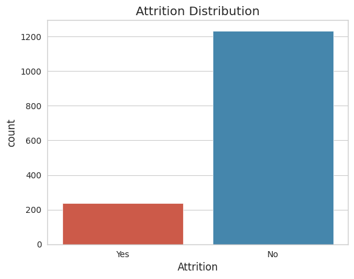

```python
sns.countplot(x="Attrition", data=df)
plt.title("Attrition Distribution")
plt.show()
```

## Age distribution by attrition

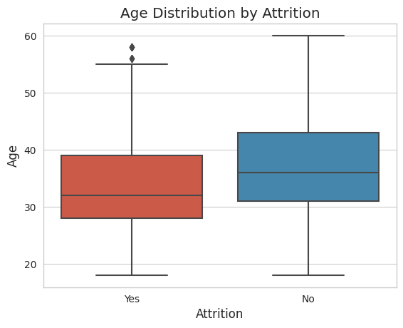

```python
sns.boxplot(x="Attrition", y="Age", data=df)
plt.title("Age Distribution by Attrition")
plt.show()
```

## Monthly Salary

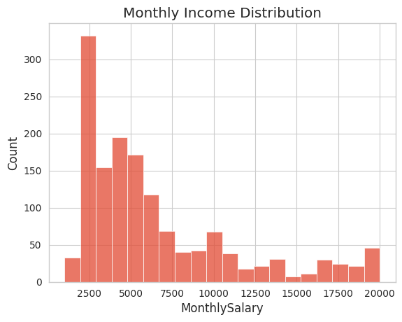

```python
sns.histplot(x="MonthlySalary", data=df)
plt.title("Monthly Income Distribution")
plt.show()
```

## See which departments have higher attrition

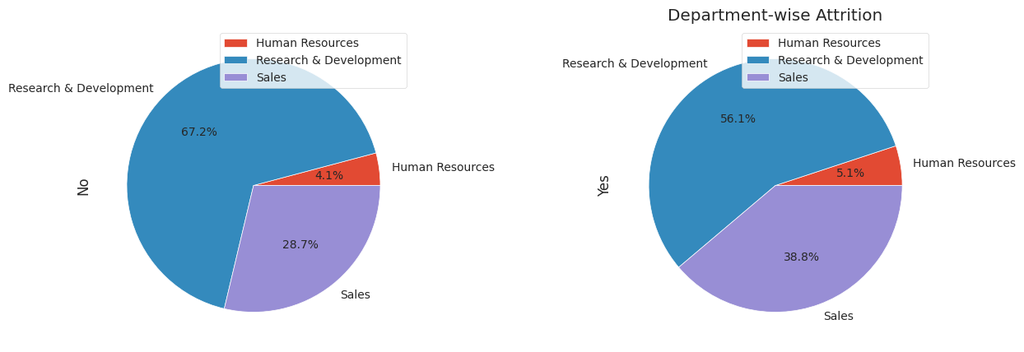

```python
df_dept = df.groupby("Department")["Attrition"].value_counts().unstack()
df_dept.plot(kind="pie", subplots=True, figsize=(15, 5), autopct="%1.1f%%")
plt.title("Department-wise Attrition")
plt.legend(loc="upper right")
plt.show()
```

## Bar plot of Attrition vs. Department

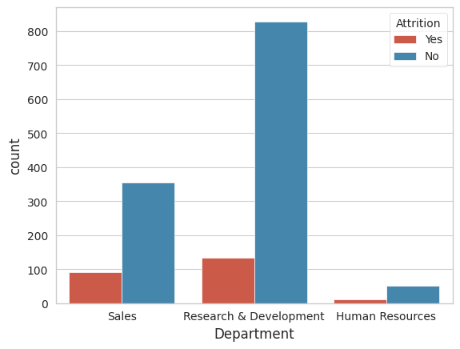

```python
sns.countplot(x='Department', hue='Attrition', data=df)
```

## Box plot of Job Level vs. Monthly Income

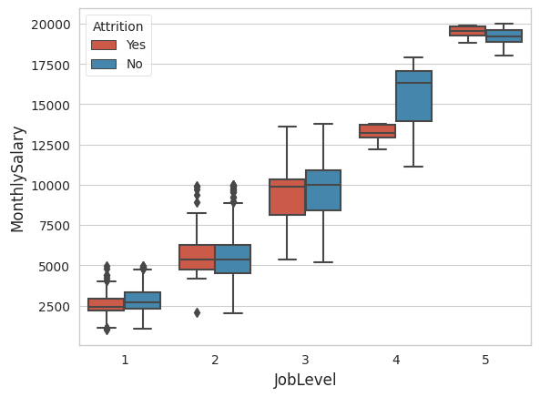

```python
sns.boxplot(x='JobLevel', y='MonthlySalary', hue='Attrition', data=df)
```

## Bar plot of Gender vs. Attrition

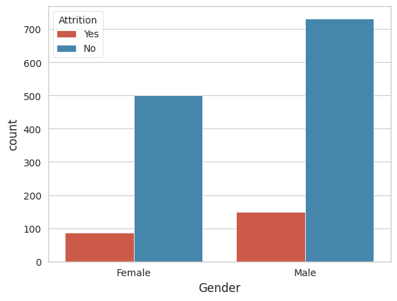

```python
sns.countplot(x='Gender', hue='Attrition', data=df)
```

# Check for fairness

```python
# We have to check for imbalances
print(df['Gender'].value_counts())
```

```
Male      882
Female    588
Name: Gender, dtype: int64
```

```python
print(df['Age'].describe())
```

```
count    1470.000000
mean       36.923810
std         9.135373
min        18.000000
25%        30.000000
50%        36.000000
75%        43.000000
max        60.000000
Name: Age, dtype: float64
```

```python
print(df['Education'].value_counts())
```

```
Bachelor         572
Master           398
College          282
Below College    170
PhD               48
Name: Education, dtype: int64
```

# Task 3 – Statistical Analysis

```python
corr_matrix = df.corr()
```

```python
print(corr_matrix)
```

```
                               Age  DailyRate  DistanceFromHome  \
Age                       1.000000   0.010661         -0.001686
DailyRate                 0.010661   1.000000         -0.004985
DistanceFromHome         -0.001686  -0.004985          1.000000
EmployeeNumber           -0.010145  -0.050990          0.032916
HourlyRate                0.024287   0.023381          0.031131
JobInvolvement            0.029820   0.046135          0.008783
JobLevel                  0.509604   0.002966          0.005303
NumCompaniesWorked        0.299635   0.038153         -0.029251
PercentSalaryHike         0.003634   0.022704          0.040235
PerformanceRating         0.001904   0.000473          0.027110
RelationshipSatisfaction  0.053535   0.007846          0.006557
StandardHours                  NaN        NaN               NaN
StockOptionLevel          0.037510   0.042143          0.044872
TotalWorkingYears         0.680381   0.014515          0.004628
TrainingTimesLastYear    -0.019621   0.002453         -0.036942
YearsAtCompany            0.311309  -0.034055          0.009508
YearsInCurrentRole        0.212901   0.009932          0.018845
YearsSinceLastPromotion   0.216513  -0.033229          0.010029
YearsWithCurrManager      0.202089  -0.026363          0.014406
MonthlySalary             0.497923   0.007763         -0.017095
Salary_Quartile           0.446871   0.020026          0.016590
PromotionFrequency        0.033971  -0.024172          0.001080

                          EmployeeNumber  HourlyRate  JobInvolvement  \
Age                            -0.010145    0.024287        0.029820
DailyRate                      -0.050990    0.023381        0.046135
DistanceFromHome                0.032916    0.031131        0.008783
EmployeeNumber                  1.000000    0.035179       -0.006888
HourlyRate                      0.035179    1.000000        0.042861
JobInvolvement                 -0.006888    0.042861        1.000000
JobLevel                       -0.018519   -0.027853       -0.012630
NumCompaniesWorked             -0.001251    0.022157        0.015012
PercentSalaryHike              -0.012944   -0.009062       -0.017205
PerformanceRating              -0.020359   -0.002172       -0.029071
RelationshipSatisfaction       -0.069861    0.001330        0.034297
StandardHours                        NaN         NaN             NaN
StockOptionLevel                0.062227    0.050263        0.021523
TotalWorkingYears              -0.014365   -0.002334       -0.005533
TrainingTimesLastYear           0.023603   -0.008548       -0.015338
```

[output cut: 138 more lines]

```
PerformanceRating             -0.017153        -0.026330           -0.024412
RelationshipSatisfaction       0.025779         0.019025            0.031474
StandardHours                       NaN              NaN                 NaN
StockOptionLevel               0.005341         0.026772           -0.013279
TotalWorkingYears              0.772912         0.664233            0.033657
TrainingTimesLastYear         -0.021932        -0.030956            0.010570
YearsAtCompany                 0.514279         0.461410            0.045069
YearsInCurrentRole             0.363815         0.392762            0.126266
YearsSinceLastPromotion        0.344983         0.311458            0.619724
YearsWithCurrManager           0.344105         0.365615            0.099916
MonthlySalary                  1.000000         0.848656            0.050126
Salary_Quartile                0.848656         1.000000            0.033025
PromotionFrequency             0.050126         0.033025            1.000000

[22 rows x 22 columns]
```

```python
corr = df.corr()
mask = np.triu(np.ones_like(corr, dtype=bool))
```

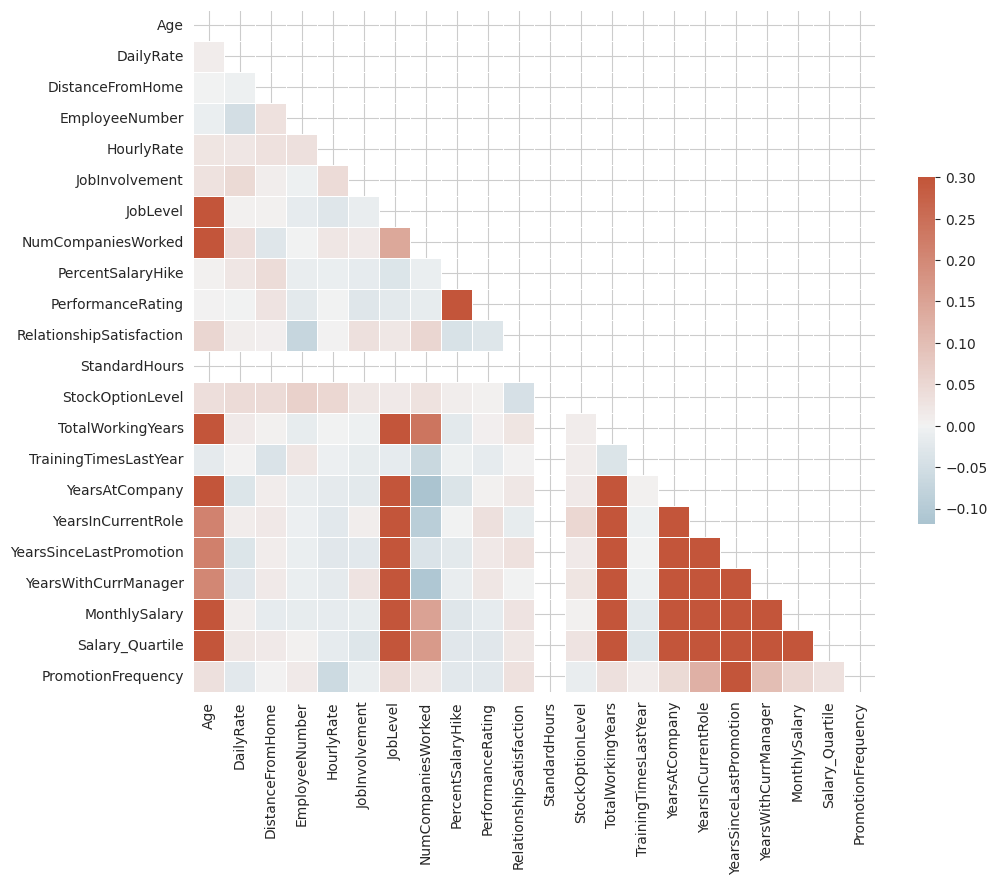

```python
fig, ax = plt.subplots(figsize=(11, 9))
cmap = sns.diverging_palette(230, 20, as_cmap=True)
sns.heatmap(corr, mask=mask, cmap=cmap, vmax=.3, center=0,
            square=True, linewidths=.5, cbar_kws={"shrink": .5})
plt.show()
```

## We are looking for a relationship between a persons monthly income and the job level they have. Here we use linear regression

```python
y = df['MonthlySalary']
X = df['JobLevel']
```

```python
X = sm.add_constant(X)
```

```python
model = sm.OLS(y, X).fit()
```

```python
print(model.summary())
```

```
                            OLS Regression Results
==============================================================================
Dep. Variable:          MonthlySalary   R-squared:                         nan
Model:                            OLS   Adj. R-squared:                    nan
Method:                 Least Squares   F-statistic:                       nan
Date:                Mon, 03 Apr 2023   Prob (F-statistic):                nan
Time:                        07:10:41   Log-Likelihood:                    nan
No. Observations:                1470   AIC:                               nan
Df Residuals:                    1468   BIC:                               nan
Df Model:                           1
Covariance Type:            nonrobust
==============================================================================
                 coef    std err          t      P>|t|      [0.025      0.975]
------------------------------------------------------------------------------
const             nan        nan        nan        nan         nan         nan
JobLevel          nan        nan        nan        nan         nan         nan
==============================================================================
Omnibus:                          nan   Durbin-Watson:                     nan
Prob(Omnibus):                    nan   Jarque-Bera (JB):                  nan
Skew:                             nan   Prob(JB):                          nan
Kurtosis:                         nan   Cond. No.                         5.68
==============================================================================

Notes:
[1] Standard Errors assume that the covariance matrix of the errors is correctly specified.
```

## Here wer do a 2 sample test for comparing the means of age of people who left company and who stayed. My hypothesis is that younger people will leave more than older people for security and family reasons

```python
attrition_yes = df[df['Attrition'] == 'Yes']
attrition_no = df[df['Attrition'] == 'No']
```

```python
t_stat, p_val = ttest_ind(attrition_yes['Age'], attrition_no['Age'], equal_var=False)
```

```python
print('t-statistic:', t_stat)
print('p-value:', p_val)
```

```
t-statistic: -5.82801185398895
p-value: 1.3797600649439775e-08
```

## We can do chi-test to check for assocation between gender and attrition

```python
cont_table = pd.crosstab(df['Attrition'], df['Gender'])
```

```python
print(cont_table)
```

```
Gender     Female  Male
Attrition
No            501   732
Yes            87   150
```

```python
chi2, p_val, dof, expected = chi2_contingency(cont_table)
```

```python
print('Chi-square statistic:', chi2)
print('Degrees of freedom:', dof)
print('p-value:', p_val)
```

```
Chi-square statistic: 1.1169671241970975
Degrees of freedom: 1
p-value: 0.29057244902890855
```

## We can do an ANOVA check, to see if the monthly income mean is different among different job types

```python
model = ols('MonthlySalary ~ JobRole', data=df).fit()
```

```python
anova_table = sm.stats.anova_lm(model, typ=2)
```

```python
print(anova_table)
```

```
                sum_sq      df           F  PR(>F)
JobRole   2.657159e+10     8.0  809.795698     0.0
Residual  5.988320e+09  1460.0         NaN     NaN
```